# Risk Factor Analysis

## Outcome Variable

**Outcome Variable:** ever_sstunted

## Predictor Variables

**Intervention Variable:** mage

**Adjustment Set:**

unadjusted

## Stratifying Variables

The analysis was stratified on these variable(s):

- agecat
- studyid
- country

## Data Summary

| agecat | studyid | country | mage | ever_sstunted | n_cell | n |
| --- | --- | --- | --- | --- | --- | --- |
| 0-24 months | ki0047075b-MAL-ED | BANGLADESH | [20-30) | 0 | 147 | 265 |
| 0-24 months | ki0047075b-MAL-ED | BANGLADESH | [20-30) | 1 | 35 | 265 |
| 0-24 months | ki0047075b-MAL-ED | BANGLADESH | <20 | 0 | 29 | 265 |
| 0-24 months | ki0047075b-MAL-ED | BANGLADESH | <20 | 1 | 8 | 265 |
| 0-24 months | ki0047075b-MAL-ED | BANGLADESH | >=30 | 0 | 31 | 265 |
| 0-24 months | ki0047075b-MAL-ED | BANGLADESH | >=30 | 1 | 15 | 265 |
| 0-24 months | ki0047075b-MAL-ED | BRAZIL | [20-30) | 0 | 124 | 233 |
| 0-24 months | ki0047075b-MAL-ED | BRAZIL | [20-30) | 1 | 15 | 233 |
| 0-24 months | ki0047075b-MAL-ED | BRAZIL | <20 | 0 | 39 | 233 |
| 0-24 months | ki0047075b-MAL-ED | BRAZIL | <20 | 1 | 4 | 233 |
| 0-24 months | ki0047075b-MAL-ED | BRAZIL | >=30 | 0 | 48 | 233 |
| 0-24 months | ki0047075b-MAL-ED | BRAZIL | >=30 | 1 | 3 | 233 |
| 0-24 months | ki0047075b-MAL-ED | INDIA | [20-30) | 0 | 148 | 249 |
| 0-24 months | ki0047075b-MAL-ED | INDIA | [20-30) | 1 | 46 | 249 |
| 0-24 months | ki0047075b-MAL-ED | INDIA | <20 | 0 | 25 | 249 |
| 0-24 months | ki0047075b-MAL-ED | INDIA | <20 | 1 | 9 | 249 |
| 0-24 months | ki0047075b-MAL-ED | INDIA | >=30 | 0 | 19 | 249 |
| 0-24 months | ki0047075b-MAL-ED | INDIA | >=30 | 1 | 2 | 249 |
| 0-24 months | ki0047075b-MAL-ED | NEPAL | [20-30) | 0 | 173 | 240 |
| 0-24 months | ki0047075b-MAL-ED | NEPAL | [20-30) | 1 | 16 | 240 |
| 0-24 months | ki0047075b-MAL-ED | NEPAL | <20 | 0 | 3 | 240 |
| 0-24 months | ki0047075b-MAL-ED | NEPAL | <20 | 1 | 2 | 240 |
| 0-24 months | ki0047075b-MAL-ED | NEPAL | >=30 | 0 | 43 | 240 |
| 0-24 months | ki0047075b-MAL-ED | NEPAL | >=30 | 1 | 3 | 240 |
| 0-24 months | ki0047075b-MAL-ED | PERU | [20-30) | 0 | 121 | 303 |
| 0-24 months | ki0047075b-MAL-ED | PERU | [20-30) | 1 | 32 | 303 |
| 0-24 months | ki0047075b-MAL-ED | PERU | <20 | 0 | 62 | 303 |
| 0-24 months | ki0047075b-MAL-ED | PERU | <20 | 1 | 21 | 303 |
| 0-24 months | ki0047075b-MAL-ED | PERU | >=30 | 0 | 56 | 303 |
| 0-24 months | ki0047075b-MAL-ED | PERU | >=30 | 1 | 11 | 303 |

[output cut: 288 more lines]

The following strata were considered:

- agecat: 0-24 months, studyid: ki0047075b-MAL-ED, country: BANGLADESH
- agecat: 0-24 months, studyid: ki0047075b-MAL-ED, country: BRAZIL
- agecat: 0-24 months, studyid: ki0047075b-MAL-ED, country: INDIA
- agecat: 0-24 months, studyid: ki0047075b-MAL-ED, country: NEPAL
- agecat: 0-24 months, studyid: ki0047075b-MAL-ED, country: PERU
- agecat: 0-24 months, studyid: ki0047075b-MAL-ED, country: SOUTH AFRICA
- agecat: 0-24 months, studyid: ki0047075b-MAL-ED, country: TANZANIA, UNITED REPUBLIC OF
- agecat: 0-24 months, studyid: ki1000108-CMC-V-BCS-2002, country: INDIA
- agecat: 0-24 months, studyid: ki1000108-IRC, country: INDIA
- agecat: 0-24 months, studyid: ki1000109-EE, country: PAKISTAN
- agecat: 0-24 months, studyid: ki1000304b-SAS-CompFeed, country: INDIA
- agecat: 0-24 months, studyid: ki1000304b-SAS-FoodSuppl, country: INDIA
- agecat: 0-24 months, studyid: ki1017093-NIH-Birth, country: BANGLADESH
- agecat: 0-24 months, studyid: ki1017093b-PROVIDE, country: BANGLADESH
- agecat: 0-24 months, studyid: ki1017093c-NIH-Crypto, country: BANGLADESH
- agecat: 0-24 months, studyid: ki1066203-TanzaniaChild2, country: TANZANIA, UNITED REPUBLIC OF
- agecat: 0-24 months, studyid: ki1101329-Keneba, country: GAMBIA
- agecat: 0-24 months, studyid: ki1112895-Guatemala BSC, country: GUATEMALA
- agecat: 0-24 months, studyid: ki1112895-iLiNS-Zinc, country: BURKINA FASO
- agecat: 0-24 months, studyid: ki1113344-GMS-Nepal, country: NEPAL
- agecat: 0-24 months, studyid: ki1119695-PROBIT, country: BELARUS
- agecat: 0-24 months, studyid: ki1126311-ZVITAMBO, country: ZIMBABWE
- agecat: 0-24 months, studyid: ki1135781-COHORTS, country: GUATEMALA
- agecat: 0-24 months, studyid: ki1135781-COHORTS, country: INDIA
- agecat: 0-24 months, studyid: ki1135781-COHORTS, country: PHILIPPINES
- agecat: 0-24 months, studyid: ki1148112-LCNI-5, country: MALAWI
- agecat: 0-24 months, studyid: kiGH5241-JiVitA-3, country: BANGLADESH
- agecat: 0-6 months, studyid: ki0047075b-MAL-ED, country: BANGLADESH
- agecat: 0-6 months, studyid: ki0047075b-MAL-ED, country: BRAZIL
- agecat: 0-6 months, studyid: ki0047075b-MAL-ED, country: INDIA
- agecat: 0-6 months, studyid: ki0047075b-MAL-ED, country: NEPAL
- agecat: 0-6 months, studyid: ki0047075b-MAL-ED, country: PERU
- agecat: 0-6 months, studyid: ki0047075b-MAL-ED, country: SOUTH AFRICA
- agecat: 0-6 months, studyid: ki0047075b-MAL-ED, country: TANZANIA, UNITED REPUBLIC OF
- agecat: 0-6 months, studyid: ki1000108-CMC-V-BCS-2002, country: INDIA
- agecat: 0-6 months, studyid: ki1000108-IRC, country: INDIA
- agecat: 0-6 months, studyid: ki1000109-EE, country: PAKISTAN
- agecat: 0-6 months, studyid: ki1000304b-SAS-CompFeed, country: INDIA
- agecat: 0-6 months, studyid: ki1000304b-SAS-FoodSuppl, country: INDIA
- agecat: 0-6 months, studyid: ki1017093-NIH-Birth, country: BANGLADESH
- agecat: 0-6 months, studyid: ki1017093b-PROVIDE, country: BANGLADESH
- agecat: 0-6 months, studyid: ki1017093c-NIH-Crypto, country: BANGLADESH
- agecat: 0-6 months, studyid: ki1066203-TanzaniaChild2, country: TANZANIA, UNITED REPUBLIC OF
- agecat: 0-6 months, studyid: ki1101329-Keneba, country: GAMBIA
- agecat: 0-6 months, studyid: ki1112895-Guatemala BSC, country: GUATEMALA
- agecat: 0-6 months, studyid: ki1113344-GMS-Nepal, country: NEPAL
- agecat: 0-6 months, studyid: ki1119695-PROBIT, country: BELARUS
- agecat: 0-6 months, studyid: ki1126311-ZVITAMBO, country: ZIMBABWE
- agecat: 0-6 months, studyid: ki1135781-COHORTS, country: GUATEMALA
- agecat: 0-6 months, studyid: ki1135781-COHORTS, country: INDIA
- agecat: 0-6 months, studyid: ki1135781-COHORTS, country: PHILIPPINES
- agecat: 0-6 months, studyid: ki1148112-LCNI-5, country: MALAWI
- agecat: 0-6 months, studyid: kiGH5241-JiVitA-3, country: BANGLADESH

### Dropped Strata

Some strata were dropped due to rare outcomes:

- agecat: 0-24 months, studyid: ki0047075b-MAL-ED, country: BRAZIL
- agecat: 0-24 months, studyid: ki0047075b-MAL-ED, country: INDIA
- agecat: 0-24 months, studyid: ki0047075b-MAL-ED, country: NEPAL
- agecat: 0-24 months, studyid: ki1000109-EE, country: PAKISTAN
- agecat: 0-6 months, studyid: ki0047075b-MAL-ED, country: BANGLADESH
- agecat: 0-6 months, studyid: ki0047075b-MAL-ED, country: BRAZIL
- agecat: 0-6 months, studyid: ki0047075b-MAL-ED, country: INDIA
- agecat: 0-6 months, studyid: ki0047075b-MAL-ED, country: NEPAL
- agecat: 0-6 months, studyid: ki0047075b-MAL-ED, country: TANZANIA, UNITED REPUBLIC OF
- agecat: 0-6 months, studyid: ki1000108-IRC, country: INDIA
- agecat: 0-6 months, studyid: ki1000109-EE, country: PAKISTAN
- agecat: 0-6 months, studyid: ki1017093b-PROVIDE, country: BANGLADESH
- agecat: 0-6 months, studyid: ki1148112-LCNI-5, country: MALAWI

## Methods Detail

We’re interested in the causal parameters $E[Y_a]$ for all values of $a \in \mathcal{A}$. These parameters represent the mean outcome if, possibly contrary to fact, we intervened to set all units to have $A=a$. Under the randomization and positivity assumptions, these are identified by the statistical parameters $\psi_a=E_W[E_{Y|A,W}(Y|A=a,W)]$. In addition, we’re interested in the mean of $Y$, $E[Y]$ under no intervention (the observed mean). We will estimate these parameters by using SuperLearner to fit the relevant likelihood factors – $E_{Y|A,W}(Y|A=a,W)$ and $p(A=a|W)$, and then updating our likelihood fit using a joint TMLE.

For unadjusted analyses ($W=\{\}$), initial likelihoods were estimated using Lrnr_glm to estimate the simple $E(Y|A)$ and Lrnr_mean to estimate $p(A)$. For adjusted analyses, a small library containing Lrnr_glmnet, Lrnr_xgboost, and Lrnr_mean was used.

Having estimated these parameters, we will then use the delta method to estimate relative risks and attributable risks relative to a prespecified baseline level of $A$.

# Results Detail

## Results Plots

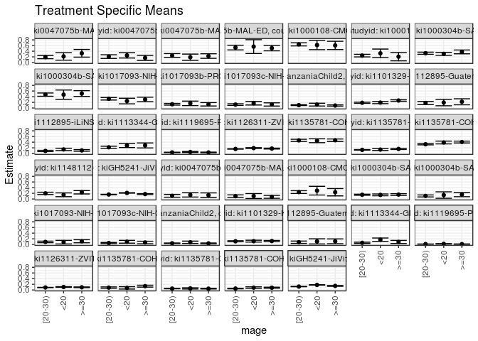

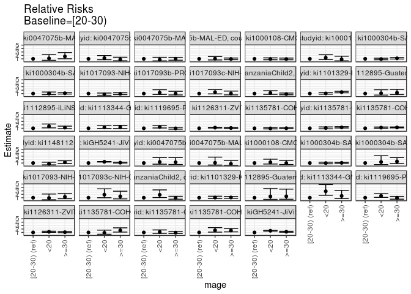

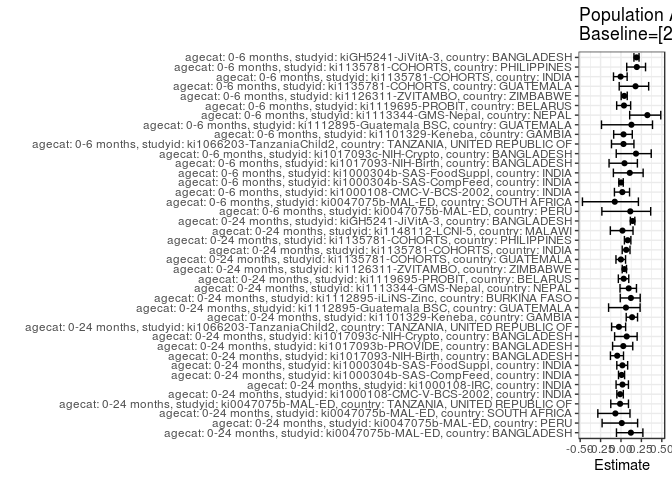

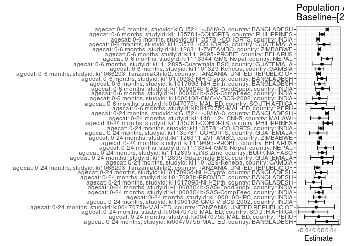

## Results Table

### Parameter: TSM

| agecat | studyid | country | intervention_level | baseline_level | estimate | ci_lower | ci_upper |
| --- | --- | --- | --- | --- | --- | --- | --- |
| 0-24 months | ki0047075b-MAL-ED | BANGLADESH | [20-30) | NA | 0.1923077 | 0.1349417 | 0.2496737 |
| 0-24 months | ki0047075b-MAL-ED | BANGLADESH | <20 | NA | 0.2162162 | 0.0833207 | 0.3491118 |
| 0-24 months | ki0047075b-MAL-ED | BANGLADESH | >=30 | NA | 0.3260870 | 0.1903623 | 0.4618116 |
| 0-24 months | ki0047075b-MAL-ED | PERU | [20-30) | NA | 0.2091503 | 0.1446003 | 0.2737004 |
| 0-24 months | ki0047075b-MAL-ED | PERU | <20 | NA | 0.2530120 | 0.1593305 | 0.3466936 |
| 0-24 months | ki0047075b-MAL-ED | PERU | >=30 | NA | 0.1641791 | 0.0753318 | 0.2530264 |
| 0-24 months | ki0047075b-MAL-ED | SOUTH AFRICA | [20-30) | NA | 0.2484472 | 0.1815936 | 0.3153008 |
| 0-24 months | ki0047075b-MAL-ED | SOUTH AFRICA | <20 | NA | 0.1875000 | 0.0769058 | 0.2980942 |
| 0-24 months | ki0047075b-MAL-ED | SOUTH AFRICA | >=30 | NA | 0.2285714 | 0.1481253 | 0.3090175 |
| 0-24 months | ki0047075b-MAL-ED | TANZANIA, UNITED REPUBLIC OF | [20-30) | NA | 0.5285714 | 0.4457249 | 0.6114179 |
| 0-24 months | ki0047075b-MAL-ED | TANZANIA, UNITED REPUBLIC OF | <20 | NA | 0.5625000 | 0.3189609 | 0.8060391 |
| 0-24 months | ki0047075b-MAL-ED | TANZANIA, UNITED REPUBLIC OF | >=30 | NA | 0.5094340 | 0.4140845 | 0.6047834 |
| 0-24 months | ki1000108-CMC-V-BCS-2002 | INDIA | [20-30) | NA | 0.6418919 | 0.5872000 | 0.6965838 |
| 0-24 months | ki1000108-CMC-V-BCS-2002 | INDIA | <20 | NA | 0.6176471 | 0.4540807 | 0.7812134 |
| 0-24 months | ki1000108-CMC-V-BCS-2002 | INDIA | >=30 | NA | 0.6046512 | 0.4583191 | 0.7509832 |
| 0-24 months | ki1000108-IRC | INDIA | [20-30) | NA | 0.2441860 | 0.1987326 | 0.2896395 |
| 0-24 months | ki1000108-IRC | INDIA | <20 | NA | 0.3243243 | 0.1733036 | 0.4753450 |
| 0-24 months | ki1000108-IRC | INDIA | >=30 | NA | 0.2068966 | 0.0592848 | 0.3545083 |
| 0-24 months | ki1000304b-SAS-CompFeed | INDIA | [20-30) | NA | 0.3281919 | 0.2908107 | 0.3655732 |
| 0-24 months | ki1000304b-SAS-CompFeed | INDIA | <20 | NA | 0.3056995 | 0.2521472 | 0.3592517 |
| 0-24 months | ki1000304b-SAS-CompFeed | INDIA | >=30 | NA | 0.3757225 | 0.3083188 | 0.4431263 |
| 0-24 months | ki1000304b-SAS-FoodSuppl | INDIA | [20-30) | NA | 0.4724138 | 0.4148861 | 0.5299415 |
| 0-24 months | ki1000304b-SAS-FoodSuppl | INDIA | <20 | NA | 0.4722222 | 0.3089487 | 0.6354957 |
| 0-24 months | ki1000304b-SAS-FoodSuppl | INDIA | >=30 | NA | 0.5108696 | 0.4086011 | 0.6131380 |
| 0-24 months | ki1017093-NIH-Birth | BANGLADESH | [20-30) | NA | 0.3270142 | 0.2822197 | 0.3718087 |
| 0-24 months | ki1017093-NIH-Birth | BANGLADESH | <20 | NA | 0.2465753 | 0.1476226 | 0.3455281 |
| 0-24 months | ki1017093-NIH-Birth | BANGLADESH | >=30 | NA | 0.3030303 | 0.2245686 | 0.3814920 |
| 0-24 months | ki1017093b-PROVIDE | BANGLADESH | [20-30) | NA | 0.1318458 | 0.1019599 | 0.1617318 |
| 0-24 months | ki1017093b-PROVIDE | BANGLADESH | <20 | NA | 0.1647059 | 0.0857975 | 0.2436143 |
| 0-24 months | ki1017093b-PROVIDE | BANGLADESH | >=30 | NA | 0.1311475 | 0.0712055 | 0.1910896 |

[output cut: 90 more lines]

### Parameter: E(Y)

| agecat | studyid | country | intervention_level | baseline_level | estimate | ci_lower | ci_upper |
| --- | --- | --- | --- | --- | --- | --- | --- |
| 0-24 months | ki0047075b-MAL-ED | BANGLADESH | NA | NA | 0.2188679 | 0.1689910 | 0.2687448 |
| 0-24 months | ki0047075b-MAL-ED | PERU | NA | NA | 0.2112211 | 0.1651858 | 0.2572564 |
| 0-24 months | ki0047075b-MAL-ED | SOUTH AFRICA | NA | NA | 0.2324841 | 0.1856873 | 0.2792809 |
| 0-24 months | ki0047075b-MAL-ED | TANZANIA, UNITED REPUBLIC OF | NA | NA | 0.5229008 | 0.4623051 | 0.5834965 |
| 0-24 months | ki1000108-CMC-V-BCS-2002 | INDIA | NA | NA | 0.6353887 | 0.5864772 | 0.6843003 |
| 0-24 months | ki1000108-IRC | INDIA | NA | NA | 0.2487805 | 0.2068840 | 0.2906770 |
| 0-24 months | ki1000304b-SAS-CompFeed | INDIA | NA | NA | 0.3307241 | 0.3024794 | 0.3589688 |
| 0-24 months | ki1000304b-SAS-FoodSuppl | INDIA | NA | NA | 0.4808612 | 0.4329065 | 0.5288160 |
| 0-24 months | ki1017093-NIH-Birth | BANGLADESH | NA | NA | 0.3125997 | 0.2762869 | 0.3489125 |
| 0-24 months | ki1017093b-PROVIDE | BANGLADESH | NA | NA | 0.1357143 | 0.1103250 | 0.1611036 |
| 0-24 months | ki1017093c-NIH-Crypto | BANGLADESH | NA | NA | 0.1306069 | 0.1066024 | 0.1546113 |
| 0-24 months | ki1066203-TanzaniaChild2 | TANZANIA, UNITED REPUBLIC OF | NA | NA | 0.0993266 | 0.0872975 | 0.1113557 |
| 0-24 months | ki1101329-Keneba | GAMBIA | NA | NA | 0.2151102 | 0.2000458 | 0.2301746 |
| 0-24 months | ki1112895-Guatemala BSC | GUATEMALA | NA | NA | 0.1886121 | 0.1427907 | 0.2344335 |
| 0-24 months | ki1112895-iLiNS-Zinc | BURKINA FASO | NA | NA | 0.1032096 | 0.0833330 | 0.1230861 |
| 0-24 months | ki1113344-GMS-Nepal | NEPAL | NA | NA | 0.2421203 | 0.2103189 | 0.2739218 |
| 0-24 months | ki1119695-PROBIT | BELARUS | NA | NA | 0.0394153 | 0.0310085 | 0.0478221 |
| 0-24 months | ki1126311-ZVITAMBO | ZIMBABWE | NA | NA | 0.1680205 | 0.1618345 | 0.1742065 |
| 0-24 months | ki1135781-COHORTS | GUATEMALA | NA | NA | 0.4639706 | 0.4374564 | 0.4904847 |
| 0-24 months | ki1135781-COHORTS | INDIA | NA | NA | 0.1370224 | 0.1277751 | 0.1462697 |
| 0-24 months | ki1135781-COHORTS | PHILIPPINES | NA | NA | 0.3561151 | 0.3391405 | 0.3730897 |
| 0-24 months | ki1148112-LCNI-5 | MALAWI | NA | NA | 0.2014925 | 0.1710974 | 0.2318877 |
| 0-24 months | kiGH5241-JiVitA-3 | BANGLADESH | NA | NA | 0.1843768 | 0.1787788 | 0.1899748 |
| 0-6 months | ki0047075b-MAL-ED | PERU | NA | NA | 0.1254125 | 0.0880603 | 0.1627648 |
| 0-6 months | ki0047075b-MAL-ED | SOUTH AFRICA | NA | NA | 0.0923567 | 0.0602816 | 0.1244318 |
| 0-6 months | ki1000108-CMC-V-BCS-2002 | INDIA | NA | NA | 0.2472826 | 0.2031431 | 0.2914222 |
| 0-6 months | ki1000304b-SAS-CompFeed | INDIA | NA | NA | 0.1496732 | 0.1307571 | 0.1685893 |
| 0-6 months | ki1000304b-SAS-FoodSuppl | INDIA | NA | NA | 0.1201923 | 0.0889059 | 0.1514788 |
| 0-6 months | ki1017093-NIH-Birth | BANGLADESH | NA | NA | 0.0940989 | 0.0712274 | 0.1169703 |
| 0-6 months | ki1017093c-NIH-Crypto | BANGLADESH | NA | NA | 0.0620053 | 0.0448256 | 0.0791849 |
| 0-6 months | ki1066203-TanzaniaChild2 | TANZANIA, UNITED REPUBLIC OF | NA | NA | 0.0433502 | 0.0351601 | 0.0515402 |
| 0-6 months | ki1101329-Keneba | GAMBIA | NA | NA | 0.1162505 | 0.1035378 | 0.1289632 |
| 0-6 months | ki1112895-Guatemala BSC | GUATEMALA | NA | NA | 0.0909091 | 0.0561653 | 0.1256529 |
| 0-6 months | ki1113344-GMS-Nepal | NEPAL | NA | NA | 0.0859599 | 0.0651504 | 0.1067694 |
| 0-6 months | ki1119695-PROBIT | BELARUS | NA | NA | 0.0142071 | 0.0107237 | 0.0176904 |
| 0-6 months | ki1126311-ZVITAMBO | ZIMBABWE | NA | NA | 0.0913177 | 0.0865488 | 0.0960866 |
| 0-6 months | ki1135781-COHORTS | GUATEMALA | NA | NA | 0.1008249 | 0.0829501 | 0.1186997 |
| 0-6 months | ki1135781-COHORTS | INDIA | NA | NA | 0.0482960 | 0.0424316 | 0.0541605 |
| 0-6 months | ki1135781-COHORTS | PHILIPPINES | NA | NA | 0.0624591 | 0.0538810 | 0.0710373 |
| 0-6 months | kiGH5241-JiVitA-3 | BANGLADESH | NA | NA | 0.1473297 | 0.1422794 | 0.1523799 |

### Parameter: RR

| agecat | studyid | country | intervention_level | baseline_level | estimate | ci_lower | ci_upper |
| --- | --- | --- | --- | --- | --- | --- | --- |
| 0-24 months | ki0047075b-MAL-ED | BANGLADESH | [20-30) | [20-30) | 1.0000000 | 1.0000000 | 1.000000 |
| 0-24 months | ki0047075b-MAL-ED | BANGLADESH | <20 | [20-30) | 1.1243243 | 0.5677789 | 2.226404 |
| 0-24 months | ki0047075b-MAL-ED | BANGLADESH | >=30 | [20-30) | 1.6956522 | 1.0161160 | 2.829634 |
| 0-24 months | ki0047075b-MAL-ED | PERU | [20-30) | [20-30) | 1.0000000 | 1.0000000 | 1.000000 |
| 0-24 months | ki0047075b-MAL-ED | PERU | <20 | [20-30) | 1.2097139 | 0.7470360 | 1.958952 |
| 0-24 months | ki0047075b-MAL-ED | PERU | >=30 | [20-30) | 0.7849813 | 0.4210188 | 1.463583 |
| 0-24 months | ki0047075b-MAL-ED | SOUTH AFRICA | [20-30) | [20-30) | 1.0000000 | 1.0000000 | 1.000000 |
| 0-24 months | ki0047075b-MAL-ED | SOUTH AFRICA | <20 | [20-30) | 0.7546875 | 0.3946455 | 1.443202 |
| 0-24 months | ki0047075b-MAL-ED | SOUTH AFRICA | >=30 | [20-30) | 0.9200000 | 0.5907199 | 1.432828 |
| 0-24 months | ki0047075b-MAL-ED | TANZANIA, UNITED REPUBLIC OF | [20-30) | [20-30) | 1.0000000 | 1.0000000 | 1.000000 |
| 0-24 months | ki0047075b-MAL-ED | TANZANIA, UNITED REPUBLIC OF | <20 | [20-30) | 1.0641892 | 0.6714992 | 1.686523 |
| 0-24 months | ki0047075b-MAL-ED | TANZANIA, UNITED REPUBLIC OF | >=30 | [20-30) | 0.9637940 | 0.7550247 | 1.230289 |
| 0-24 months | ki1000108-CMC-V-BCS-2002 | INDIA | [20-30) | [20-30) | 1.0000000 | 1.0000000 | 1.000000 |
| 0-24 months | ki1000108-CMC-V-BCS-2002 | INDIA | <20 | [20-30) | 0.9622291 | 0.7285538 | 1.270853 |
| 0-24 months | ki1000108-CMC-V-BCS-2002 | INDIA | >=30 | [20-30) | 0.9419829 | 0.7288118 | 1.217505 |
| 0-24 months | ki1000108-IRC | INDIA | [20-30) | [20-30) | 1.0000000 | 1.0000000 | 1.000000 |
| 0-24 months | ki1000108-IRC | INDIA | <20 | [20-30) | 1.3281853 | 0.8043984 | 2.193038 |
| 0-24 months | ki1000108-IRC | INDIA | >=30 | [20-30) | 0.8472906 | 0.4053311 | 1.771148 |
| 0-24 months | ki1000304b-SAS-CompFeed | INDIA | [20-30) | [20-30) | 1.0000000 | 1.0000000 | 1.000000 |
| 0-24 months | ki1000304b-SAS-CompFeed | INDIA | <20 | [20-30) | 0.9314655 | 0.7352995 | 1.179966 |
| 0-24 months | ki1000304b-SAS-CompFeed | INDIA | >=30 | [20-30) | 1.1448256 | 0.9412200 | 1.392475 |
| 0-24 months | ki1000304b-SAS-FoodSuppl | INDIA | [20-30) | [20-30) | 1.0000000 | 1.0000000 | 1.000000 |
| 0-24 months | ki1000304b-SAS-FoodSuppl | INDIA | <20 | [20-30) | 0.9995945 | 0.6928244 | 1.442197 |
| 0-24 months | ki1000304b-SAS-FoodSuppl | INDIA | >=30 | [20-30) | 1.0814027 | 0.8555123 | 1.366937 |
| 0-24 months | ki1017093-NIH-Birth | BANGLADESH | [20-30) | [20-30) | 1.0000000 | 1.0000000 | 1.000000 |
| 0-24 months | ki1017093-NIH-Birth | BANGLADESH | <20 | [20-30) | 0.7540203 | 0.4934278 | 1.152238 |
| 0-24 months | ki1017093-NIH-Birth | BANGLADESH | >=30 | [20-30) | 0.9266579 | 0.6913592 | 1.242039 |
| 0-24 months | ki1017093b-PROVIDE | BANGLADESH | [20-30) | [20-30) | 1.0000000 | 1.0000000 | 1.000000 |
| 0-24 months | ki1017093b-PROVIDE | BANGLADESH | <20 | [20-30) | 1.2492308 | 0.7353000 | 2.122368 |
| 0-24 months | ki1017093b-PROVIDE | BANGLADESH | >=30 | [20-30) | 0.9947037 | 0.5972080 | 1.656768 |

[output cut: 90 more lines]

### Parameter: PAR

| agecat | studyid | country | intervention_level | baseline_level | estimate | ci_lower | ci_upper |
| --- | --- | --- | --- | --- | --- | --- | --- |
| 0-24 months | ki0047075b-MAL-ED | BANGLADESH | [20-30) | NA | 0.0265602 | -0.0089121 | 0.0620326 |
| 0-24 months | ki0047075b-MAL-ED | PERU | [20-30) | NA | 0.0020708 | -0.0435142 | 0.0476558 |
| 0-24 months | ki0047075b-MAL-ED | SOUTH AFRICA | [20-30) | NA | -0.0159631 | -0.0615271 | 0.0296008 |
| 0-24 months | ki0047075b-MAL-ED | TANZANIA, UNITED REPUBLIC OF | [20-30) | NA | -0.0056707 | -0.0622418 | 0.0509005 |
| 0-24 months | ki1000108-CMC-V-BCS-2002 | INDIA | [20-30) | NA | -0.0065032 | -0.0317243 | 0.0187180 |
| 0-24 months | ki1000108-IRC | INDIA | [20-30) | NA | 0.0045944 | -0.0142326 | 0.0234215 |
| 0-24 months | ki1000304b-SAS-CompFeed | INDIA | [20-30) | NA | 0.0025321 | -0.0096488 | 0.0147131 |
| 0-24 months | ki1000304b-SAS-FoodSuppl | INDIA | [20-30) | NA | 0.0084475 | -0.0234438 | 0.0403387 |
| 0-24 months | ki1017093-NIH-Birth | BANGLADESH | [20-30) | NA | -0.0144145 | -0.0393979 | 0.0105689 |
| 0-24 months | ki1017093b-PROVIDE | BANGLADESH | [20-30) | NA | 0.0038684 | -0.0128556 | 0.0205925 |
| 0-24 months | ki1017093c-NIH-Crypto | BANGLADESH | [20-30) | NA | 0.0091494 | -0.0088535 | 0.0271522 |
| 0-24 months | ki1066203-TanzaniaChild2 | TANZANIA, UNITED REPUBLIC OF | [20-30) | NA | -0.0025194 | -0.0110375 | 0.0059988 |
| 0-24 months | ki1101329-Keneba | GAMBIA | [20-30) | NA | 0.0293064 | 0.0143126 | 0.0443002 |
| 0-24 months | ki1112895-Guatemala BSC | GUATEMALA | [20-30) | NA | 0.0114692 | -0.0247400 | 0.0476784 |
| 0-24 months | ki1112895-iLiNS-Zinc | BURKINA FASO | [20-30) | NA | 0.0125613 | 0.0000291 | 0.0250934 |
| 0-24 months | ki1113344-GMS-Nepal | NEPAL | [20-30) | NA | 0.0228810 | -0.0015663 | 0.0473283 |
| 0-24 months | ki1119695-PROBIT | BELARUS | [20-30) | NA | 0.0013248 | -0.0012818 | 0.0039313 |
| 0-24 months | ki1126311-ZVITAMBO | ZIMBABWE | [20-30) | NA | 0.0070072 | 0.0026119 | 0.0114024 |
| 0-24 months | ki1135781-COHORTS | GUATEMALA | [20-30) | NA | -0.0004772 | -0.0277430 | 0.0267885 |
| 0-24 months | ki1135781-COHORTS | INDIA | [20-30) | NA | 0.0087603 | 0.0021981 | 0.0153226 |
| 0-24 months | ki1135781-COHORTS | PHILIPPINES | [20-30) | NA | 0.0293499 | 0.0152802 | 0.0434196 |
| 0-24 months | ki1148112-LCNI-5 | MALAWI | [20-30) | NA | 0.0036903 | -0.0242146 | 0.0315952 |
| 0-24 months | kiGH5241-JiVitA-3 | BANGLADESH | [20-30) | NA | 0.0262790 | 0.0211693 | 0.0313888 |
| 0-6 months | ki0047075b-MAL-ED | PERU | [20-30) | NA | 0.0143014 | -0.0227196 | 0.0513225 |
| 0-6 months | ki0047075b-MAL-ED | SOUTH AFRICA | [20-30) | NA | -0.0070222 | -0.0382348 | 0.0241904 |
| 0-6 months | ki1000108-CMC-V-BCS-2002 | INDIA | [20-30) | NA | 0.0041319 | -0.0187459 | 0.0270097 |
| 0-6 months | ki1000304b-SAS-CompFeed | INDIA | [20-30) | NA | 0.0001887 | -0.0038404 | 0.0042177 |
| 0-6 months | ki1000304b-SAS-FoodSuppl | INDIA | [20-30) | NA | 0.0129259 | -0.0090278 | 0.0348795 |
| 0-6 months | ki1017093-NIH-Birth | BANGLADESH | [20-30) | NA | 0.0040515 | -0.0122133 | 0.0203163 |
| 0-6 months | ki1017093c-NIH-Crypto | BANGLADESH | [20-30) | NA | 0.0113980 | -0.0020788 | 0.0248748 |
| 0-6 months | ki1066203-TanzaniaChild2 | TANZANIA, UNITED REPUBLIC OF | [20-30) | NA | 0.0013387 | -0.0046058 | 0.0072832 |
| 0-6 months | ki1101329-Keneba | GAMBIA | [20-30) | NA | 0.0036225 | -0.0096022 | 0.0168472 |
| 0-6 months | ki1112895-Guatemala BSC | GUATEMALA | [20-30) | NA | 0.0116408 | -0.0164860 | 0.0397676 |
| 0-6 months | ki1113344-GMS-Nepal | NEPAL | [20-30) | NA | 0.0277943 | 0.0104552 | 0.0451335 |
| 0-6 months | ki1119695-PROBIT | BELARUS | [20-30) | NA | 0.0005197 | -0.0007083 | 0.0017478 |
| 0-6 months | ki1126311-ZVITAMBO | ZIMBABWE | [20-30) | NA | 0.0036691 | 0.0002769 | 0.0070614 |
| 0-6 months | ki1135781-COHORTS | GUATEMALA | [20-30) | NA | 0.0179624 | -0.0003170 | 0.0362418 |
| 0-6 months | ki1135781-COHORTS | INDIA | [20-30) | NA | -0.0002254 | -0.0042543 | 0.0038035 |
| 0-6 months | ki1135781-COHORTS | PHILIPPINES | [20-30) | NA | 0.0121033 | 0.0047561 | 0.0194506 |
| 0-6 months | kiGH5241-JiVitA-3 | BANGLADESH | [20-30) | NA | 0.0280679 | 0.0234208 | 0.0327151 |

### Parameter: PAF

| agecat | studyid | country | intervention_level | baseline_level | estimate | ci_lower | ci_upper |
| --- | --- | --- | --- | --- | --- | --- | --- |
| 0-24 months | ki0047075b-MAL-ED | BANGLADESH | [20-30) | NA | 0.1213528 | -0.0551853 | 0.2683551 |
| 0-24 months | ki0047075b-MAL-ED | PERU | [20-30) | NA | 0.0098039 | -0.2313314 | 0.2037170 |
| 0-24 months | ki0047075b-MAL-ED | SOUTH AFRICA | [20-30) | NA | -0.0686633 | -0.2835665 | 0.1102594 |
| 0-24 months | ki0047075b-MAL-ED | TANZANIA, UNITED REPUBLIC OF | [20-30) | NA | -0.0108446 | -0.1250434 | 0.0917622 |
| 0-24 months | ki1000108-CMC-V-BCS-2002 | INDIA | [20-30) | NA | -0.0102349 | -0.0507397 | 0.0287084 |
| 0-24 months | ki1000108-IRC | INDIA | [20-30) | NA | 0.0184679 | -0.0601792 | 0.0912807 |
| 0-24 months | ki1000304b-SAS-CompFeed | INDIA | [20-30) | NA | 0.0076563 | -0.0303153 | 0.0442285 |
| 0-24 months | ki1000304b-SAS-FoodSuppl | INDIA | [20-30) | NA | 0.0175673 | -0.0510639 | 0.0817172 |
| 0-24 months | ki1017093-NIH-Birth | BANGLADESH | [20-30) | NA | -0.0461118 | -0.1291560 | 0.0308249 |
| 0-24 months | ki1017093b-PROVIDE | BANGLADESH | [20-30) | NA | 0.0285043 | -0.1027913 | 0.1441682 |
| 0-24 months | ki1017093c-NIH-Crypto | BANGLADESH | [20-30) | NA | 0.0700528 | -0.0780238 | 0.1977896 |
| 0-24 months | ki1066203-TanzaniaChild2 | TANZANIA, UNITED REPUBLIC OF | [20-30) | NA | -0.0253644 | -0.1147652 | 0.0568668 |
| 0-24 months | ki1101329-Keneba | GAMBIA | [20-30) | NA | 0.1362391 | 0.0640203 | 0.2028857 |
| 0-24 months | ki1112895-Guatemala BSC | GUATEMALA | [20-30) | NA | 0.0608086 | -0.1518042 | 0.2341750 |
| 0-24 months | ki1112895-iLiNS-Zinc | BURKINA FASO | [20-30) | NA | 0.1217063 | -0.0088893 | 0.2353970 |
| 0-24 months | ki1113344-GMS-Nepal | NEPAL | [20-30) | NA | 0.0945025 | -0.0119541 | 0.1897599 |
| 0-24 months | ki1119695-PROBIT | BELARUS | [20-30) | NA | 0.0336102 | -0.0322430 | 0.0952621 |
| 0-24 months | ki1126311-ZVITAMBO | ZIMBABWE | [20-30) | NA | 0.0417042 | 0.0152133 | 0.0674825 |
| 0-24 months | ki1135781-COHORTS | GUATEMALA | [20-30) | NA | -0.0010286 | -0.0615539 | 0.0560459 |
| 0-24 months | ki1135781-COHORTS | INDIA | [20-30) | NA | 0.0639335 | 0.0149393 | 0.1104908 |
| 0-24 months | ki1135781-COHORTS | PHILIPPINES | [20-30) | NA | 0.0824169 | 0.0420421 | 0.1210902 |
| 0-24 months | ki1148112-LCNI-5 | MALAWI | [20-30) | NA | 0.0183150 | -0.1304048 | 0.1474687 |
| 0-24 months | kiGH5241-JiVitA-3 | BANGLADESH | [20-30) | NA | 0.1425290 | 0.1146197 | 0.1695586 |
| 0-6 months | ki0047075b-MAL-ED | PERU | [20-30) | NA | 0.1140351 | -0.2342485 | 0.3640391 |
| 0-6 months | ki0047075b-MAL-ED | SOUTH AFRICA | [20-30) | NA | -0.0760334 | -0.4719807 | 0.2134082 |
| 0-6 months | ki1000108-CMC-V-BCS-2002 | INDIA | [20-30) | NA | 0.0167093 | -0.0802810 | 0.1049916 |
| 0-6 months | ki1000304b-SAS-CompFeed | INDIA | [20-30) | NA | 0.0012605 | -0.0260265 | 0.0278218 |
| 0-6 months | ki1000304b-SAS-FoodSuppl | INDIA | [20-30) | NA | 0.1075433 | -0.0931481 | 0.2713896 |
| 0-6 months | ki1017093-NIH-Birth | BANGLADESH | [20-30) | NA | 0.0430557 | -0.1460825 | 0.2009803 |
| 0-6 months | ki1017093c-NIH-Crypto | BANGLADESH | [20-30) | NA | 0.1838229 | -0.0582042 | 0.3704948 |
| 0-6 months | ki1066203-TanzaniaChild2 | TANZANIA, UNITED REPUBLIC OF | [20-30) | NA | 0.0308813 | -0.1162912 | 0.1586506 |
| 0-6 months | ki1101329-Keneba | GAMBIA | [20-30) | NA | 0.0311614 | -0.0895043 | 0.1384630 |
| 0-6 months | ki1112895-Guatemala BSC | GUATEMALA | [20-30) | NA | 0.1280488 | -0.2387775 | 0.3862506 |
| 0-6 months | ki1113344-GMS-Nepal | NEPAL | [20-30) | NA | 0.3233408 | 0.1066395 | 0.4874771 |
| 0-6 months | ki1119695-PROBIT | BELARUS | [20-30) | NA | 0.0365827 | -0.0527436 | 0.1183296 |
| 0-6 months | ki1126311-ZVITAMBO | ZIMBABWE | [20-30) | NA | 0.0401798 | 0.0023536 | 0.0765719 |
| 0-6 months | ki1135781-COHORTS | GUATEMALA | [20-30) | NA | 0.1781544 | -0.0218844 | 0.3390347 |
| 0-6 months | ki1135781-COHORTS | INDIA | [20-30) | NA | -0.0046667 | -0.0916470 | 0.0753832 |
| 0-6 months | ki1135781-COHORTS | PHILIPPINES | [20-30) | NA | 0.1937803 | 0.0702734 | 0.3008803 |
| 0-6 months | kiGH5241-JiVitA-3 | BANGLADESH | [20-30) | NA | 0.1905111 | 0.1587628 | 0.2210613 |